# Data 602 - In Class Notes for October 11

Here’s a change I applied

**Time to Play With Data A:**

**(a)**

```r
oct6ttp1.df <- read.csv("https://raw.githubusercontent.com/Statman44/Data602/main/baseball.csv")
```

```r
oct6ttp1.df = oct6ttp1.df %>%
  mutate(winpct = wins/(wins + losses))
```

```r
head(oct6ttp1.df, 4)
```

|  | franchise | league | division | year | attendance | runs.scored | runs.allowed | wins | losses | games.behind |
| --- | --- | --- | --- | --- | --- | --- | --- | --- | --- | --- |
| 1 | BAL | AL | EAST | 69 | 1062069 | 779 | 517 | 109 | 53 | 0.0 |
| 2 | BOS | AL | EAST | 69 | 1833246 | 743 | 736 | 87 | 75 | 22.0 |
| 3 | CLE | AL | EAST | 69 | 619970 | 573 | 717 | 62 | 99 | 46.5 |
| 4 | DET | AL | EAST | 69 | 1577481 | 701 | 601 | 90 | 72 | 19.0 |

```r
tail(oct6ttp1.df, 4)
```

|  | franchise | league | division | year | attendance | runs.scored | runs.allowed | wins | losses | games.behind |
| --- | --- | --- | --- | --- | --- | --- | --- | --- | --- | --- |
| 835 | COL | NL | WEST | 0 | 3285710 | 968 | 897 | 82 | 80 | 15.0 |
| 836 | FL | NL | EAST | 0 | 1218326 | 731 | 797 | 79 | 82 | 15.5 |
| 837 | ARI | NL | WEST | 0 | 2942516 | 792 | 754 | 85 | 77 | 12.0 |
| 838 | MILN | NL | CENT | 0 | 1573621 | 740 | 826 | 73 | 89 | 22.0 |

The scatterplot of the two variables **winpct** and average home **attendance** is provided below, where **attendance** is the total season attendance @ home games for a MLB team.

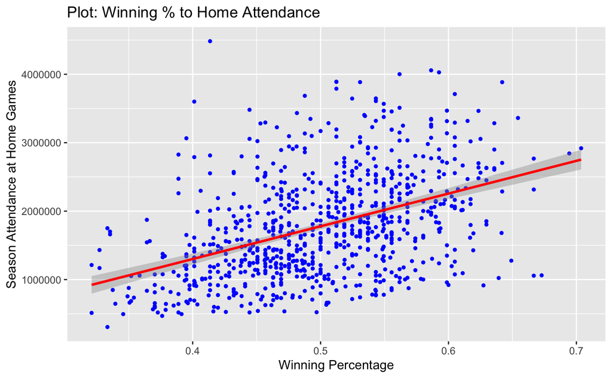

```r
options(scipen=999)
ggplot(oct6ttp1.df, aes(x = winpct, y = attendance)) + geom_point(col="blue", size=1, position = "jitter") + xlab("Winning Percentage") + ylab("Season Attendance at Home Games") + ggtitle("Plot: Winning % to Home Attendance") + geom_smooth(method="lm", col="red")
```

```r
favstats(~attendance, data=oct6ttp1.df)
favstats(~winpct, data=oct6ttp1.df)
```

**(b)** The correlation coefficient is computed with

```r
cor(~winpct, ~attendance, data=oct6ttp1.df)
```

and
$$r = 0.436598 \approx 0.4366$$

Note how the sign on $r$ is positive? And note the “numerical value” of $r$…..

**Time to Play With Data B:**

**(a)** Estimate the least squares line that estimates the model
$$SeasonAttendance_{i} = A + (B*WinPct_{i}) + e_{i}$$

Using the `lm` command:

```r
predict.seasonattendance <- lm(attendance ~ winpct, data = oct6ttp1.df)
```

```r
predict.seasonattendance$coef
```

**(b)** Winning percentage of **winpct = 0.405**?

$$\begin{eqnarray}
\widehat{SeasonAttendance}_{i} & = & -612607.7 +
(4782137.1*0.405) \\
& = & 1324158 \:\:
\text{persons/fans}
\end{eqnarray}$$

```r
-612607.7 + (4782137.1*0.405)
```

This can be done with the `predict` command:

```r
predict(predict.seasonattendance, data.frame(winpct=0.405))
```

Meaning? Consider all MLB baseball teams that have a winning percentage of 0.405: The mean/average home attendance for such baseball teams is 1324158 persons/fans in a season.

Consider **winpct = 0.608**?

```r
predict(predict.seasonattendance, data.frame(winpct=0.608))
```

$$\widehat{SeasonAttendance}_{i} = 2,294,932 \:\:\text{persons/fans}$$
——————-

**Time to Play With Data C:**

Check the conditions of the model.

In this instance, I am going create a data frame called **ttpdiagnostic.df**:

```r
attendance.fits <- predict.seasonattendance$fitted.values #assigns predicted values to one vector
attendance.values <- oct6ttp1.df$attendance #assigns observed values of y to another vector
attendance.residuals <- predict.seasonattendance$residuals #assigns residuals to another vectdor
```

```r
ttpdiagnostic.df <- data.frame(attendance.values, attendance.fits, attendance.residuals)
```

```r
ttpdiagnostic.df
```

**(a)** A Normal probability plot of the residuals

```r
ggplot(ttpdiagnostic.df, aes(sample = attendance.residuals)) + stat_qq(col="blue", size = 1) + stat_qqline(col="red") + ggtitle("Normal Probability Plot of Residuals/Error Terms")
```

[output not shown]

This checks the condition of *normalcy* in the residuals - AKA, the $y$-variable home season attendance fluctuates from one team to the next in accordance with a Normal distribution.

**(b)**

A residual plot:

```r
ggplot(ttpdiagnostic.df, aes(x = attendance.fits, y = attendance.residuals)) + geom_point(col="blue", size=1) + xlab("Predicted Values of Home Attendance in a Season") + ylab("Residuals") + ggtitle("Residual Plot") + geom_hline(yintercept=0, col="red", linetype="dashed")
```

[output not shown]

**Time to Play With Data D:**

1. Compute the value of $S_{e}$, which is used to estimate the common standard deviation $\sigma$ in the $y$-variable (home season attendance), regardless of the value of the $x$-variable (winning percentage)

```r
sum(ttpdiagnostic.df$attendance.residuals^2)
sqrt(sum(ttpdiagnostic.df$attendance.residuals^2)/(838 - 2))  #note, n = 838
```

from which

$$S_{e} = \sqrt{\frac{SSE}{n - 2}} = \sqrt{\frac{ 387058460537948}{838 -
2}} = 680432.6$$
Alternatively, this can be obtained with the `aov` function

```r
aov(predict.seasonattendance)
```

from which
$$SSR = 91156224715423 \hspace{0.5in} \text{and} \hspace{0.5in} SSE =
387058460537948 \hspace{0.5in} S_{e} = 680432.6$$

The coefficient of determination $r^{2}$ is

```r
rsquared(predict.seasonattendance)
```

and
$$r^{2} = \frac{91156224715423}{91156224715423 + 387058460537948} =
0.1906178$$

19.06% of the variation in the season attendance can be explained by its linear relationship with/dependency on the MLB team’s winning percentage.

**Time to Play With Data E:** Compute the values of the standard deviation of the statistics $a$ and $b$.

```r
coef(summary(predict.seasonattendance))
```

From this output,
$$S_{a} = 171986.2 \hspace{1in} S_{b} = 340811.3$$

**Time To Play With Data F:**

**(a)** The confidence interval for $A$, which in this case is the mean/average home attendance for a MLB team that has a **winpct = 0**:

```r
confint(predict.seasonattendance)
```

from which the 95% confidence interval for $A$ is
$$-950183.1 \leq A \leq -275032.2$$

**(b)** If the $A$ term is negligible to the model, then $A = 0$:
$${\rm H}_{0}: A = 0 \hspace{1in} {\rm H}_{A}: A \ne 0 \:\: \text{(this
term is not negligible to the model)}$$
The test statistic computed is
$$T_{Obs} = \frac{a - A^{*}}{S_{a}} = \frac{-612607.7 - 0}{171986.2} =
-3.562$$
The $P$-value is
$$P-\text{value} = P(T_{838 - 2} <
-3.562)*\underbrace{2}_{\text{two-tailed test}} = 0.0003889$$

```r
pt(-3.562, 838 - 2)*2
```

```r
coef(summary(predict.seasonattendance))
```

$${\rm H}_{0}: A = -200000...\text{adjust the test statistic according}$$
**Time to Play With Data G:** In this exercise, the focus is on the slope of the model $B$, which is where the relationship between the $x$-variable **winpct** and the $y$-variable **attendance** is encapsulated.

**(a)** To test the claim that $B = 0$ is the same as testing that a team’s home attendance is not linearly related to the team’s winning percentage, and therefore winning percentage has NO EFFECT on a team’s home attendance.

```r
(1 - pt(14.032, 838 - 2))*2
```

**(b)** Since the null hypothesis is rejected in part (a), and one CAN express a MLB baseball team’s season attendance as a linear function of their winning percentage, the 95% confidence interval for $B$ is (obtained above)

winpct 4113190.7 5451083.4

$$4113190.7 \leq B \leq 5451083.4 \longrightarrow 41131.9 \leq ? \leq
54510.8$$
The second version of the confidence interval corresponds to an increase in the $x$-variable by 0.01, in this instance an increase in the winning percentage by 1%. As a MLB baseball team’s winning percentage increases by 1%, their season home attendance will increase by an AVERAGE of anywhere between 41132 to 54511 people/fans.

**Time to Paly With Data H:**

Here is the ANOVA table:

```r
summary(aov(predict.seasonattendance))
```

From which
$$F_{Obs} = \frac{91156224715423/1}{387058460537948/836} = 196.9$$

```r
1 - pf(196.9, 1, 838-2)
```

Note that
$$T^{2}_{Obs, B = 0} = (14.032)^2 = 196.897 \approx 196.9 = F_{Obs}$$
The $P$-value of the $F$-test of linear appropriateness is
$$P-\text{value} = P(F_{1, 838 - 2} > 196.9) \approx 0$$
The value of $F_{Obs}$ can also be obtained via the `summary` command below:

```r
summary(predict.seasonattendance)
```

**Time to Play With Data I:**

```r
predict(predict.seasonattendance, newdata=data.frame(winpct=0.535), interval = "predict")
```

From this output:

$$\widehat{SeasonAttendance}_{i} = -612607.7 + (4782137.1*0.535) = 1945836
\\
609275.7 \leq SeasonAttendance_{x = 0.535} \leq 3282396$$
A baseball team with a season winning percentage of 0.535, or 53.5%, will have a total season attendance somewhere betweeen 609276 persons and 3282396 persons.

**(b)** Capture $\mu_{SeasonAttendance|winpct = 0.500}$:

```r
predict(predict.seasonattendance, newdata=data.frame(winpct=0.500), interval = "conf")
```

From this output:

$$\widehat{SeasonAttendance}_{i} = -612607.7 + (4782137.1*0.500) = 1778461
\\
1732325 \leq \mu_{SeasonAttendance|x = 0.500} \leq 1824597$$
For all MLB baseball teams with a 0.500, or 50%, winning percentage, the mean/average season attendance is somewhere between 1732325 to 1824597 persons.